# Predict’em all

Andrew Lee

Pokémon Go is an AR mobile game launched in 2016. It locates Pokémon as if they are in the player’s real-world location. To the players of Pokémon Go, it has been well known that the number of Pokémon we can encounter varies depending on the type of Pokémon and the surrounding conditions. For example, Squirtle belongs to the Water type, so the players could expect to see more Squirtle when they are playing the game nearby lakes or sea. In addition, when the players are nearby pokestop or gym, where players could obtain game items, players can expect to see many Pokémon.

Meanwhile, if we imagine subdividing all the geolocation into small areas, the probability of encountering a Pokémon in a single subdivided area is small, but the number of areas is many. In this case, Poisson distribution is a good approximation and can be used for predicting the number of Pokémon sightings. So, in this project, I tried to build a regression model which can predict the number of Pokémon sightings, using Poisson distribution.

# Data Preparation

#### Sum HABCDS of each Pokemons

HABCDS stands for Pokémon’s six major stats—HP, Attack, Block (Defense), Contact (Special Attack), Defense (Special Defense), and Speed. The summation of the all 6 HABCDS is often used as IVs, the Individual values, which are instrumental in determining how a Pokémon strong in the battle. In Pokémon Go, it has been well know to the players that Pokémon with large IVs rarely appears, while those with small IVs commonly appears.

```r
BS = apply(pokedex[,9:14], 1, sum)
pokedex = cbind(pokedex, BS)
```

```r
# merge by pokemon ID
names(pokedex)[1] = "pokemonId"
raw.data = merge(x = raw.data, y = pokedex, by = "pokemonId", all.x = TRUE)

# pokestopDistanceKm
raw.data$pokestopDistanceKm[raw.data$pokestopDistanceKm == "?"] = NA
raw.data$pokestopDistanceKm = as.numeric(paste(raw.data$pokestopDistanceKm))
```

#### Terrain type

```r
sort(unique(raw.data$terrainType))
```

```
##  [1]  0  1  2  4  5  7  8  9 10 11 12 13 14 16
```

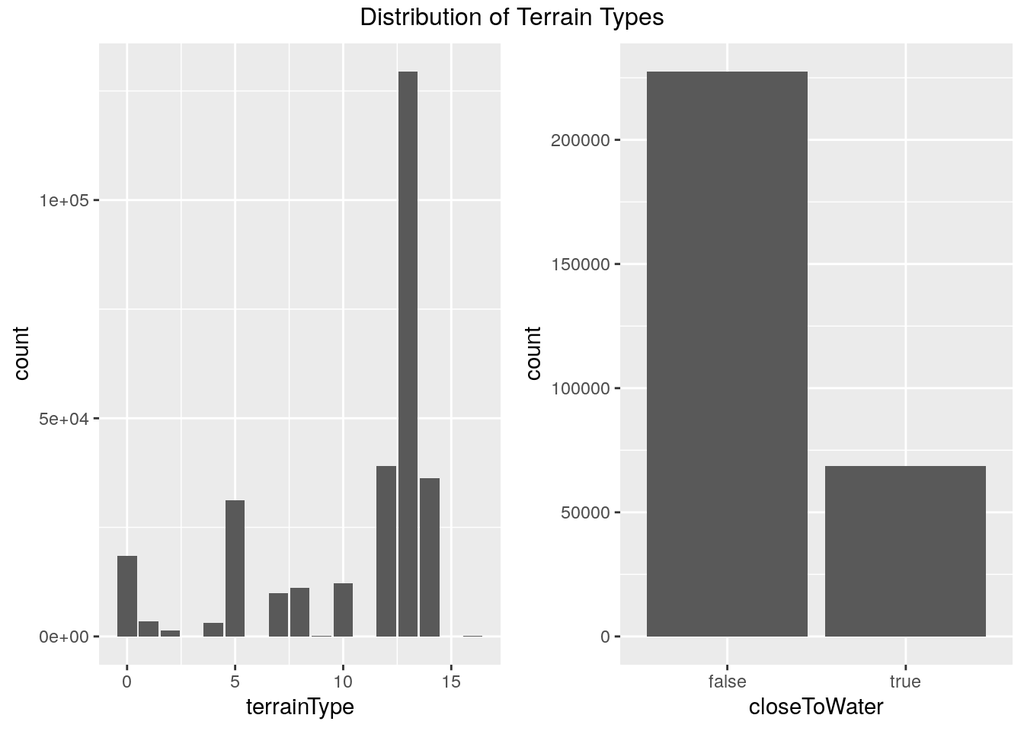

```r
p1 = ggplot(data = raw.data, aes(terrainType)) +
       geom_bar()
p2 = ggplot(data = raw.data, aes(closeToWater)) +
       geom_bar()

grid.arrange(p1, p2, ncol = 2, top = "Distribution of Terrain Types")
```

In the raw data, the terrain type is provided by GLCF Modis Land Cover (numeric). You can find detailed description from here: https://yceo.yale.edu/modis-land-cover-product-mcd12q1 (See Classification Schemes 1 - 4). As you can see, some of the Terrain types can be merged together. For example, from type 1 to 5, it is reasonable to merge data as forest. This would prevent consumption of the degrees of freedom in the model discussed later.

```r
attach(raw.data)
raw.data = mutate(raw.data, Terrain = ifelse(closeToWater == TRUE | terrainType == 0 | terrainType == 11, "Water",
                                             ifelse(terrainType >= 1 & terrainType <= 5, "Forest",
                                                    ifelse(terrainType >= 7 & terrainType <= 10, "Grass",
                                                           ifelse(terrainType == 13, "Urban",
                                                                  ifelse(terrainType == 12 | terrainType == 14, "Cropland", "Barren"))))))
detach(raw.data)
```

An overview of the distribution of the Terrain in the raw data is:

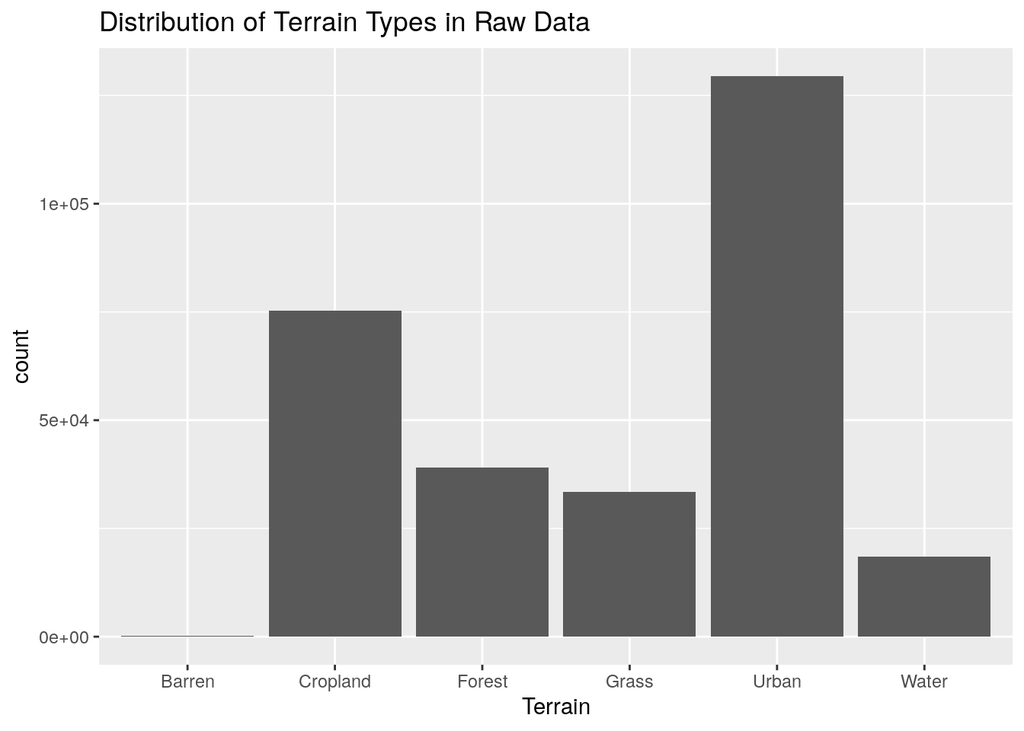

```r
ggplot(data = raw.data, aes(Terrain)) +
  geom_bar() +
  labs(title = "Distribution of Terrain Types in Raw Data")
```

### Weather

```r
unique(raw.data$weatherIcon)
```

```
## [1] partly-cloudy-day   rain                wind
## [4] partly-cloudy-night clear-night         clear-day
## [7] fog                 cloudy
## 8 Levels: clear-day clear-night cloudy fog ... wind
```

https://bulbapedia.bulbagarden.net/wiki/Weather

According to Bulbapedia, the type of weather in Pokémon Go is partly cloudy, cloudy, rain, windy, fog, and clear. So, I merged some of the values in weatherIcon as below.

```r
attach(raw.data)
raw.data = mutate(raw.data, Weather = ifelse(weatherIcon == "partly-cloudy-day" | weatherIcon == "partly-cloudy-night", "partly-cloudy",
                                             ifelse(weatherIcon == "rain", "rain",
                                                    ifelse(weatherIcon == "wind", "windy",
                                                           ifelse(weatherIcon == "clear-night" | weatherIcon == "clear-day", "clear",
                                                                  ifelse(weatherIcon == "fog", "fog", "cloudy"))))))
detach(raw.data)
```

An overview of the distribution of the Weather in the raw data is:

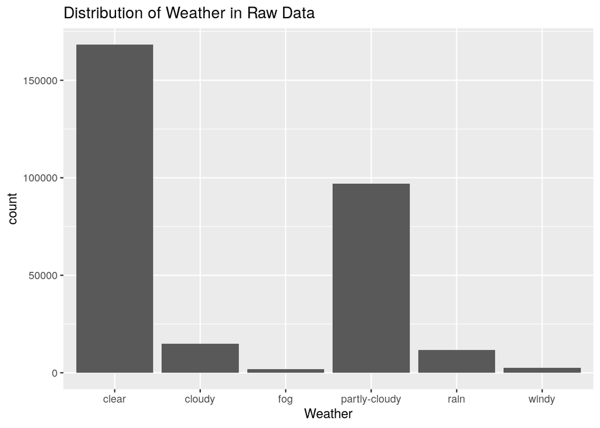

```r
ggplot(data = raw.data, aes(Weather)) +
  geom_bar() +
  labs(title = "Distribution of Weather in Raw Data")
```

# Summarize by Pokemon appearance

Before we start to build the regression model, we first need to sum over the number of observations in our raw data by each Pokémon according to combinations of conditions (categorical values such as terrain type, weather, etc.). One of the problems I faced on this summarization is that a Pokémon could possibly belong to more than 1 types. For example, Burbasaur belongs to both Grass and Poison type. According to the Niantic team, developer of Pokémon Go, Pokémon of two different types will appear as boosted when it has favorable conditions for either of the types. In other words, if we use only one of two different types, we may miss some important relations between types and conditions in the regression model.

In order to solve this problem, I divided raw data into two different groups; one is Pokémon with single type, and the other is Pokémon with two different types. For the Pokémon with single type, we have no problem on summarizing the number of observations, grouping by Pokémon ID, type, terrain, and weather. On the other hand, for the Pokémon with two different types, I first did the same summarization twice; one is using only first of two different types, and the other is using only second of two different types. So, we have exactly the same datasets with the same order, but different Pokémon types. After that, I generated random integers for each of the Pokémon appearance cases (random integer 1 and 2; the length of the random integers is same as the length of summarization data), and extract rows from two summarized datasets depending on the random integers. Finally, I bound all three datasets, single type Pokémon, first type Pokémon, and second type Pokémon.

```r
# pokemon only with primary type
primary = raw.data[is.na(raw.data$type_2) == TRUE,]
# pokemon with both primary and secondary type
secondary = raw.data[is.na(raw.data$type_2) == FALSE,]

secondary.1 = secondary[,c(1:5,7:9)]
secondary.2 = secondary[,c(1:4,6:9)]

colnames(primary)[which(names(primary) == "type_1")] = "type"
colnames(secondary.1)[which(names(secondary.1) == "type_1")] = "type"
colnames(secondary.2)[which(names(secondary.2) == "type_2")] = "type"

secondary.count.1 = secondary.1 %>%
  group_by(pokemonId, type, Terrain, Weather) %>%
  count()
secondary.count.1 = as.data.frame(secondary.count.1)

pokestop.1 = secondary.1 %>%
  group_by(pokemonId, type, Terrain, Weather) %>%
  summarise(pokestop = mean(pokestopDistanceKm, na.rm = TRUE))

gym.1 = secondary.1 %>%
  group_by(pokemonId, type, Terrain, Weather) %>%
  summarise(gym = mean(gymDistanceKm, na.rm = TRUE))

BS.1 = secondary.1 %>%
  group_by(pokemonId, type, Terrain, Weather) %>%
  summarise(BS = mean(BS))

#Secondary.app.1 is Pokemon with first of their two different types.
secondary.app.1 = cbind(secondary.count.1, pokestop.1[,5], gym.1[,5], BS.1[,5])
```

```r
secondary.count.2 = secondary.2 %>%
  group_by(pokemonId, type, Terrain, Weather) %>%
  count()
secondary.count.2 = as.data.frame(secondary.count.2)

pokestop.2 = secondary.2 %>%
  group_by(pokemonId, type, Terrain, Weather) %>%
  summarise(pokestop = mean(pokestopDistanceKm, na.rm = TRUE))

gym.2 = secondary.2 %>%
  group_by(pokemonId, type, Terrain, Weather) %>%
  summarise(gym = mean(gymDistanceKm, na.rm = TRUE))

BS.2 = secondary.2 %>%
  group_by(pokemonId, type, Terrain, Weather) %>%
  summarise(BS = mean(BS))

#Secondary.app.2 is Pokemon with first of their two different types.
secondary.app.2 = cbind(secondary.count.2, pokestop.2[,5], gym.2[,5], BS.2[,5])
```

Two datasets have same order, same values. The only difference is ‘type’.

```r
Id = unique(secondary.app.1$pokemonId)
Id
```

```
##  [1]   1   2   3   6  12  13  14  15  16  17  18  21  22  31  34  39  40
## [18]  41  42  43  44  45  46  47  48  49  62  69  70  71  72  73  74  75
## [35]  76  79  80  81  82  83  84  85  87  91  92  93  94  95 102 103 111
## [52] 112 121 122 123 124 130 131 138 139 140 141 142 149
```

```r
sample = list()


for(i in 1:length(Id)){
  subset = secondary.app.1[secondary.app.1$pokemonId == Id[i],]
  set.seed(1123)
  sample[[i]] = sample.int(2, size = nrow(subset), replace = TRUE)
}

sample = unlist(sample)
```

```r
secondary.app.1 = cbind(secondary.app.1, sample)
secondary.app.1 = secondary.app.1[secondary.app.1$sample == 1,]
secondary.app.2 = cbind(secondary.app.2, sample)
secondary.app.2 = secondary.app.2[secondary.app.2$sample == 2,]
```

```r
secondary.appear = rbind(secondary.app.1, secondary.app.2)
secondary.appear = secondary.appear[,1:8]
```

```r
primary.count = primary %>%
  group_by(pokemonId, type, Terrain, Weather) %>%
  count()
primary.count = as.data.frame(primary.count)

pokestop.3 = primary %>%
  group_by(pokemonId, type, Terrain, Weather) %>%
  summarise(pokestop = mean(pokestopDistanceKm, na.rm = TRUE))

gym.3 = primary %>%
  group_by(pokemonId, type, Terrain, Weather) %>%
  summarise(gym = mean(gymDistanceKm, na.rm = TRUE))

BS.3 = primary %>%
  group_by(pokemonId, type, Terrain, Weather) %>%
  summarise(BS = mean(BS))

primary.appear = cbind(primary.count, pokestop.3[,5], gym.3[,5], BS.3[,5])
```

```r
appear.data = rbind(primary.appear, secondary.appear)
appear.data$Terrain = as.factor(appear.data$Terrain)
appear.data$Weather = as.factor(appear.data$Weather)
```

After summarizing data, I dropped some of the factor levels unused in the dataset. Such leves exist, because there are some legendary Pokémon, which never appears in general. Also, there might be some conditions where there would be no players, such as in desert or high mountains.

```r
appear.data$Terrain = droplevels(appear.data$Terrain)
appear.data$Weather = droplevels(appear.data$Weather)
appear.data$type = droplevels(appear.data$type)
```

# Some Data Exploration

A compact overview of the summarized data is:

```r
summary(appear.data)
```

```
##    pokemonId           type         Terrain             Weather
##  Min.   :  1.00   water  :489   Barren  : 54   clear        :699
##  1st Qu.: 32.00   poison :425   Cropland:589   cloudy       :427
##  Median : 67.00   normal :287   Forest  :460   fog          :201
##  Mean   : 69.16   bug    :179   Grass   :410   partly-cloudy:623
##  3rd Qu.:104.00   psychic:163   Urban   :657   rain         :422
##  Max.   :149.00   ground :160   Water   :433   windy        :231
##                   (Other):900
##        n              pokestop             gym                  BS
##  Min.   :    1.0   Min.   :  0.0052   Min.   :   0.0134   Min.   :195.0
##  1st Qu.:    2.0   1st Qu.:  0.1525   1st Qu.:   0.3341   1st Qu.:305.0
##  Median :    8.0   Median :  0.2895   Median :   0.6345   Median :340.0
##  Mean   :  113.7   Mean   :  1.7444   Mean   :   4.5915   Mean   :368.4
##  3rd Qu.:   42.0   3rd Qu.:  0.6589   3rd Qu.:   1.8338   3rd Qu.:450.0
##  Max.   :11903.0   Max.   :453.8491   Max.   :1929.8107   Max.   :600.0
##
```

- **type:** type of the appeared Pokémon, there are 17 different types in the dataset, including bug, dragon, and fighting. *factor*
- **Terrain:** type of the location where Pokémon appeared, there are 6 different types of terrain. *factor*
- **Weather:** type of weather condition when Pokémon appeared, there are 6 different types of weather conditions. *factor*
- **pokestop:** average distance to the nearest pokestop by conditions on weather, terrain, and type (in km). *numeric*
- **gym:** average distance to the nearest gym by conditions on weather, terrain, and type (in km). *numeric*
- **BS:** average IVs by conditions on weather, terrain, and type. *integer*
- **n:** the number of Pokémon appeared with the given condition. *integer*

PokeStops and Gym are places in Pokémon Go that allow players to collect items such as eggs and more Poke Balls to capture more Pokemon or battle the Pokémon of rival teams. From the overview above, we notice that there are some outliers in Distance to Pokestop and Distance to Gym.

```r
head(unique(sort(appear.data$pokestop, decreasing = TRUE)), 30)
```

```
##  [1] 453.84906 453.72697 227.50471 200.51651 151.91553 151.90509 136.62506
##  [8] 113.97924  84.83611  82.91704  75.89304  65.44135  57.40098  55.77551
## [15]  55.40570  55.21521  41.93161  36.29566  34.61072  34.19812  29.95225
## [22]  24.03136  22.36256  22.33288  22.16470  20.75913  20.14191  19.16250
## [29]  18.69730  18.69468
```

```r
head(unique(sort(appear.data$gym, decreasing = TRUE)), 30)
```

```
##  [1] 1929.81069  453.84906  453.72697  227.60250  203.25931  162.69679
##  [7]  153.02156  152.35641  151.93876  151.87628  136.89373  114.00774
## [13]  109.64932  109.13291  102.67354  101.98397  101.77702  101.52025
## [19]   84.83611   83.04563   79.47909   77.48867   77.27093   76.13440
## [25]   72.20766   66.89480   65.65407   62.43788   62.35197   61.38653
```

Since it is not realistic not to see any of Pokestop within 100km, I decided to drop the observations with pokestop greater than 100. Similarly, I decided to drop the observations with gym greater than 100.

```r
appear.data = appear.data[appear.data$pokestop < 100,]
appear.data = appear.data[appear.data$gym < 100,]
```

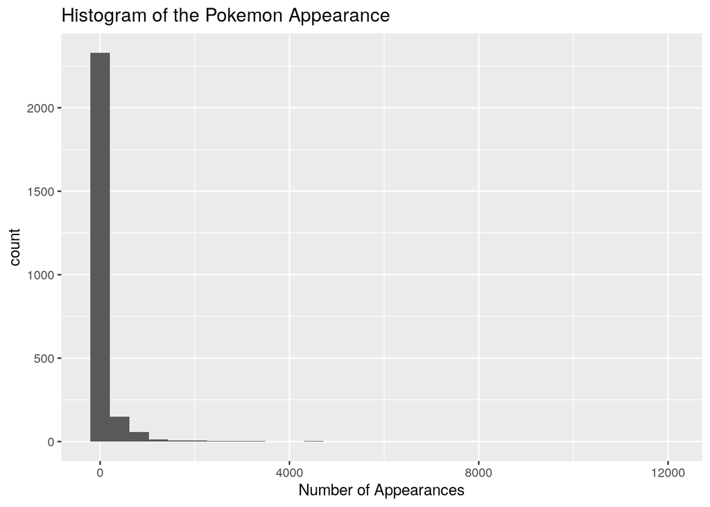

```r
ggplot(appear.data, aes(n)) +
  geom_histogram() +
  labs(title = "Histogram of the Pokemon Appearance", x = "Number of Appearances")
```

As we can see in the plot above, the number of Pokémon sightings seems to follow Poisson distribution.

If Y is Poisson with mean $\mu>0$, then $P(Y=y)$=$\displaystyle \frac{e^{-\mu}\mu^y}{y!}$, for y = 0, 1, 2, … Poison distribution is good approximation for the number of successes with small success probabilities and large totals. In this project, if we see encountering Pokémon in the world as success, the number of Pokémon we could encounter could be approximated by using Poison distribution.

The following plots also shows that the number of sightings of Pokémon might follow Poisson distribution in each of the categorical variable level.

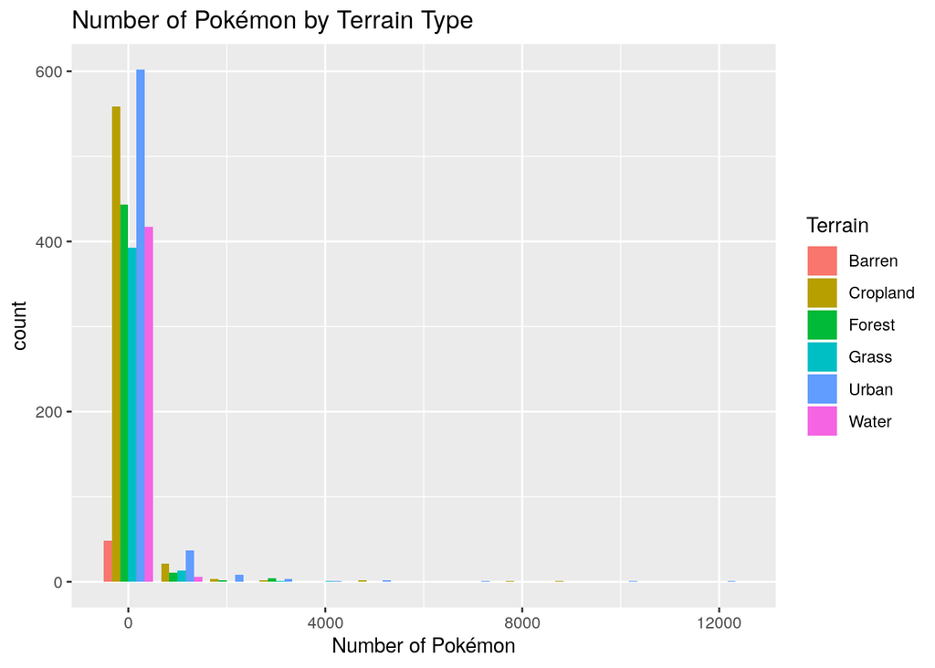

```r
ggplot(appear.data, aes(n, fill = Terrain)) +
  geom_histogram(binwidth=1000, position="dodge") +
  labs(x = "Number of Pokémon", title = "Number of Pokémon by Terrain Type")
```

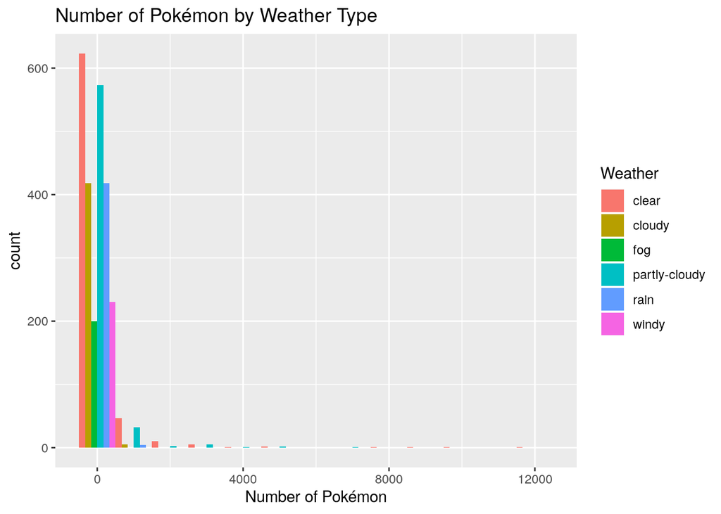

```r
ggplot(appear.data, aes(n, fill = Weather)) +
  geom_histogram(binwidth=1000, position="dodge") +
  labs(x = "Number of Pokémon", title = "Number of Pokémon by Weather Type")
```

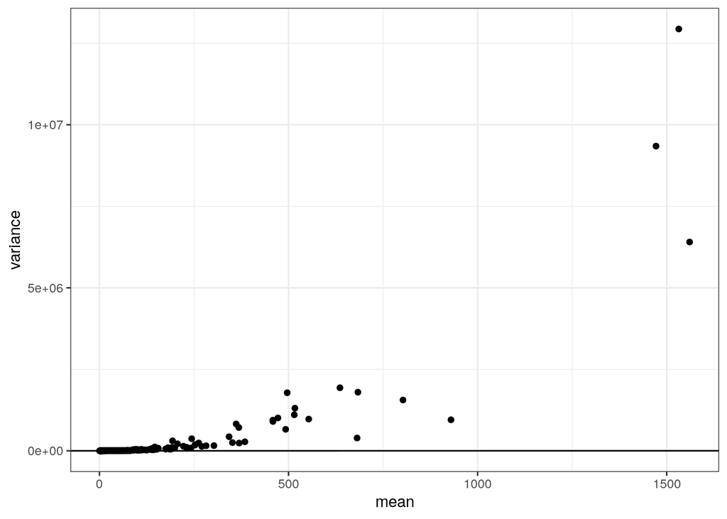

```r
df = appear.data %>%
  group_by(Terrain, type, Weather) %>%
  summarize(nvar = var(n), nmean = mean(n))

ggplot(df, aes(x = nmean, y = nvar)) +
  geom_point() +
  geom_abline(a = 0, b = 1) +
  theme_bw() +
  labs(y = 'variance', x= 'mean')
```

In Poisson distribution, mean and variance has the same value. However, if we see the plot, we can notice that there is over dispersion. For each levels of means, there is much higher levels of variances in the plot. Quick remedy for this problem is to use Quasi-poisson instead of Poisson distribution in the regression model.

The number of Pokémon under the combination of type and terrain is as below. We see that the distribution of the number of Pokémon changes depending on the terrain types.

```r
xtabs(~ Terrain + type, appear.data)
```

```
##           type
## Terrain    bug dragon electric fairy fighting fire flying ghost grass
##   Barren     0      1        1     0        2    4      8     0     3
##   Cropland  28      9       19    21       24   32     46     2    22
##   Forest    35      7       17    11       15   21     27     7    30
##   Grass     34      5       14    14       20   28     16     4    24
##   Urban     40     12       27    13       26   42     40     6    34
##   Water     40      7       15    11       14   22     14     6    27
##           type
## Terrain    ground ice normal poison psychic rock steel water
##   Barren        5   0      4      5       1    2     0    12
##   Cropland     36   7     57    124      44   11     6   101
##   Forest       24  10     54     69      28   12     3    90
##   Grass        30   3     46     60      26   13     3    68
##   Urban        41   7     73    106      42   20     3   124
##   Water        19   4     50     61      22   14     5    92
```

Similarly, the number of Pokémon under the combination of type and weather is as below. We see that the distribution of the number of Pokémon changes depending on the weather types.

```r
xtabs(~ Weather + type, appear.data)
```

```
##                type
## Weather         bug dragon electric fairy fighting fire flying ghost grass
##   clear          39     12       28    18       30   49     43     5    26
##   cloudy         36      7       14    11       18   20     21     4    22
##   fog            20      2        4     5        4    8     13     3    22
##   partly-cloudy  36     12       27    15       27   39     35     6    37
##   rain           29      6       14    15       16   21     25     4    24
##   windy          17      2        6     6        6   12     14     3     9
##                type
## Weather         ground ice normal poison psychic rock steel water
##   clear             50  10     73    120      41   24     5   119
##   cloudy            19   5     49     70      29   11     5    82
##   fog               10   1     23     25      11    4     0    45
##   partly-cloudy     46  11     65     93      34   20     4   110
##   rain              22   3     42     72      32   10     4    83
##   windy              8   1     32     45      16    3     2    48
```

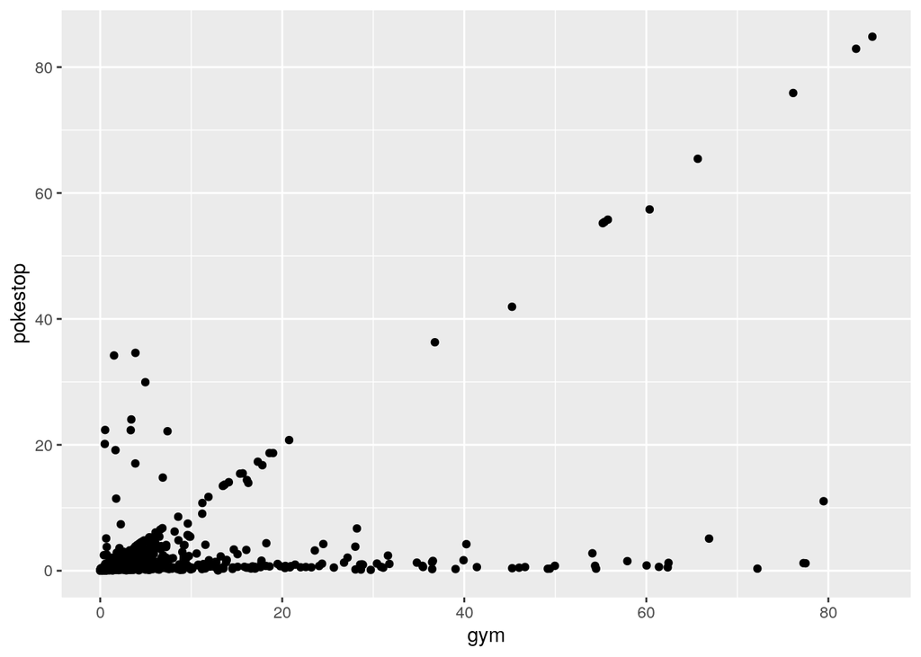

```r
ggplot(data = appear.data, aes(gym, pokestop)) +
  geom_point()
```

In the scatter plot above, we see that there might be some positive correlation between the distance to pokestop and the distance to gym.

# Model Fitting

In the initial model, we have the interaction term between type and terrain, type and weather. We also have the distance to pokestop, distance to gym, and IVs. Using F-test, we can drop terms which cannot decrease deviance in the number of Pokémon sightings that much.

```r
m1 = glm(n ~ type*Terrain + type*Weather + pokestop + gym + BS, data=appear.data, family = 'quasipoisson')
drop1(m1, test = "F")
```

```
## Single term deletions
##
## Model:
## n ~ type * Terrain + type * Weather + pokestop + gym + BS
##              Df Deviance   F value    Pr(>F)
## <none>            222064
## pokestop      1   222066    0.0211  0.884461
## gym           1   222078    0.1487  0.699838
## BS            1   664312 4779.6813 < 2.2e-16 ***
## type:Terrain 75   240910    2.7158 4.232e-13 ***
## type:Weather 79   233144    1.5158  0.002576 **
## ---
## Signif. codes:  0 '***' 0.001 '**' 0.01 '*' 0.05 '.' 0.1 ' ' 1
```

```r
m2 = glm(n ~ type*Terrain + type*Weather + pokestop + BS, data=appear.data, family = 'quasipoisson')
drop1(m2, test = "F")
```

```
## Single term deletions
##
## Model:
## n ~ type * Terrain + type * Weather + pokestop + BS
##              Df Deviance   F value    Pr(>F)
## <none>            222078
## pokestop      1   222090    0.1342  0.714143
## BS            1   665239 4791.2548 < 2.2e-16 ***
## type:Terrain 75   240962    2.7222  3.66e-13 ***
## type:Weather 79   233144    1.5145  0.002625 **
## ---
## Signif. codes:  0 '***' 0.001 '**' 0.01 '*' 0.05 '.' 0.1 ' ' 1
```

```r
m3 = glm(n ~ type*Terrain + type*Weather + BS, data=appear.data, family = 'quasipoisson')
drop1(m3, test = "F")
```

```
## Single term deletions
##
## Model:
## n ~ type * Terrain + type * Weather + BS
##              Df Deviance   F value    Pr(>F)
## <none>            222090
## BS            1   665276 4793.2475 < 2.2e-16 ***
## type:Terrain 75   241003    2.7273 3.262e-13 ***
## type:Weather 79   233151    1.5143  0.002634 **
## ---
## Signif. codes:  0 '***' 0.001 '**' 0.01 '*' 0.05 '.' 0.1 ' ' 1
```

In the final model, we have the interaction term between type and weather, interaction term between type and terrain, IVs. The final model explains about 82% of the deviance.

```r
1 - (m3$deviance/m3$null.deviance)
```

```
## [1] 0.8221993
```

# Prediction

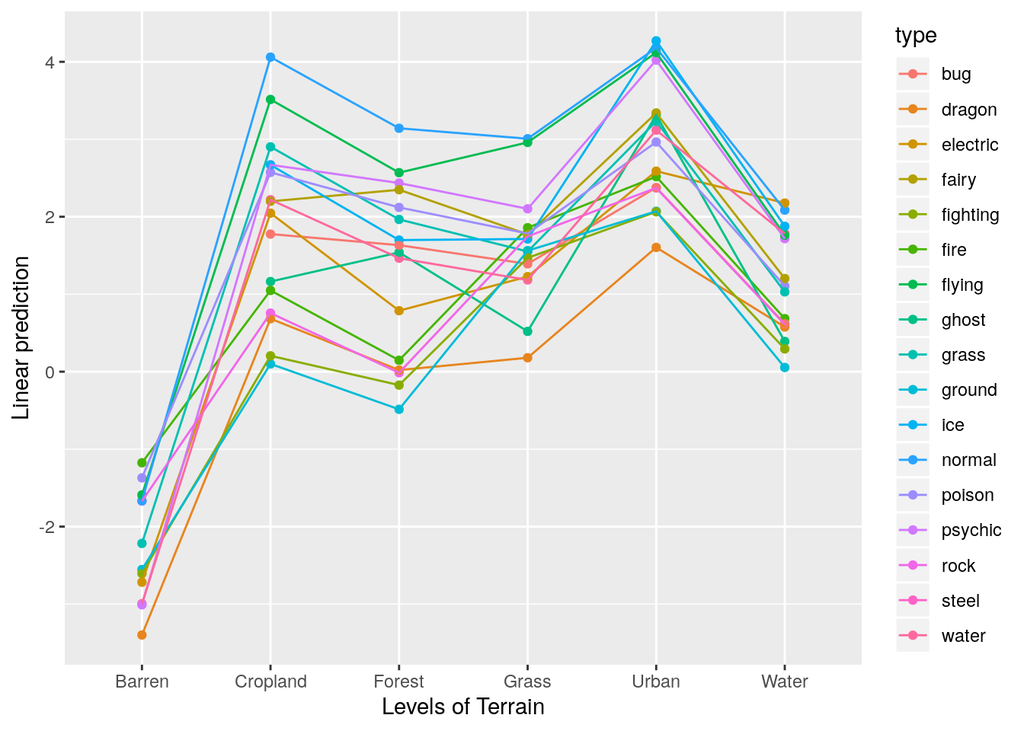

```r
#comparisons
emmip(m3, type~Terrain)
```

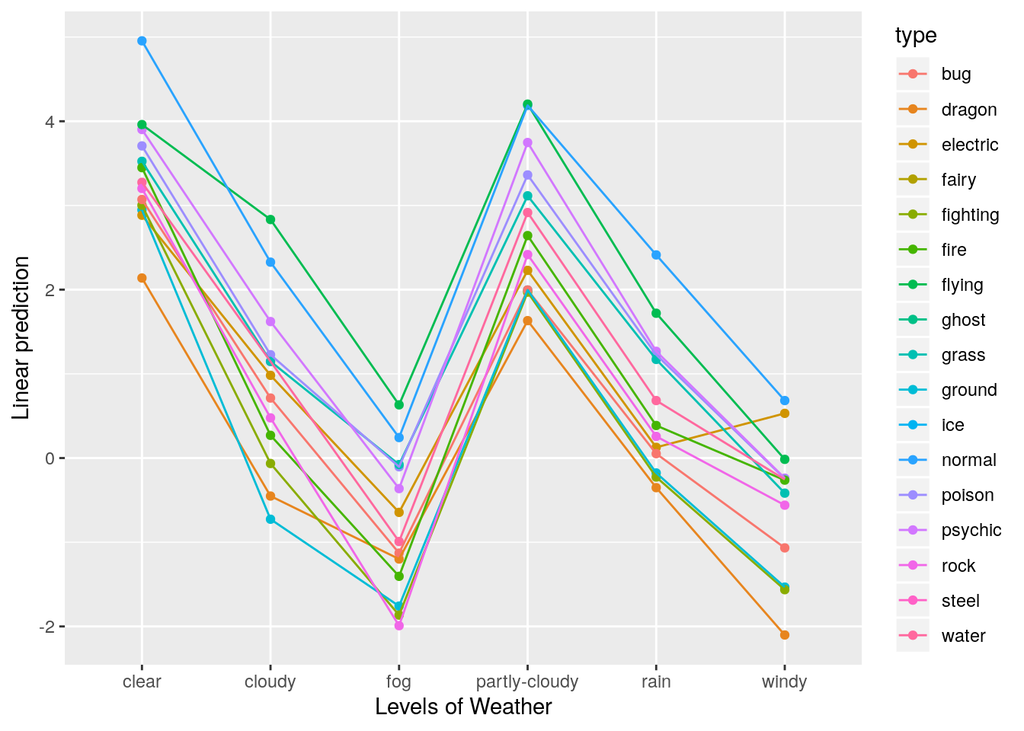

```r
emmip(m3, type~Weather)
```

We see that clear interaction between type and terrain. Although for most of the types, linear prediction goes same by the levels of weather, some of the Pokémon types shows different pattern depending on weather levels. For example, compared to the clear days, while all types of Pokémon has less linear prediction in cloudy days, the flying type Pokémon in those days appears more than the other types. Note that the Linear prediction in the above plots are not the number of Pokémon, but the exponents.

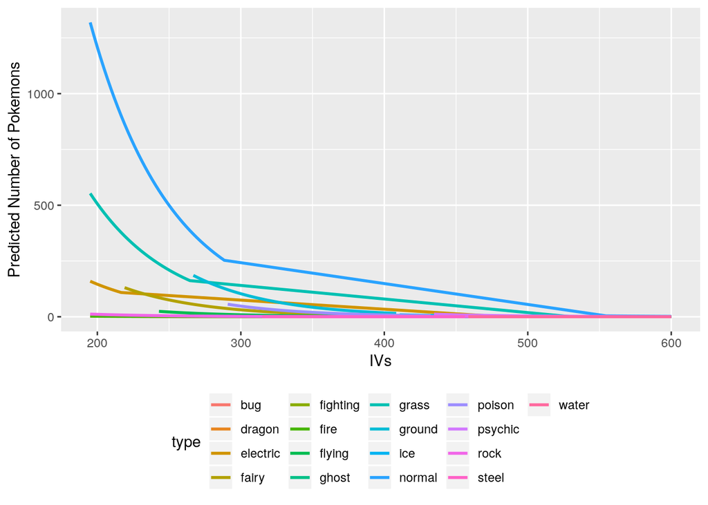

```r
new.data = data.frame(
  BS = rep(seq(from = min(appear.data$BS), to = max(appear.data$BS), length.out = 170), 6),
  type = factor(rep(1:17, each = 60), levels = 1:17, labels = levels(appear.data$type)),
  Terrain = factor(rep(1:6, each = 170), levels = 1:6, labels = levels(appear.data$Terrain)),
  Weather = factor(rep(1:6, each = 170), levels = 1:6, labels = levels(appear.data$Weather)))

new.data = cbind(new.data, predict(m3, new.data, type = "link", se.fit=TRUE))
new.data = within(new.data, {
  n = exp(fit)
})

ggplot(new.data, aes(BS, n)) +
  geom_line(aes(color = type), size = 1) +
  labs(x = "IVs", y = "Predicted Number of Pokemons") +
  theme(legend.position="bottom")
```

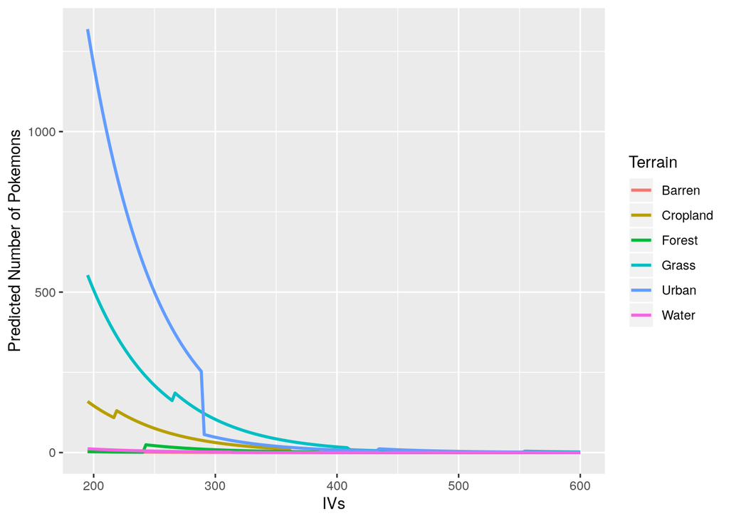

```r
ggplot(new.data, aes(BS, n)) +
  geom_line(aes(color = Terrain), size = 1) +
  labs(x = "IVs", y = "Predicted Number of Pokemons")
```

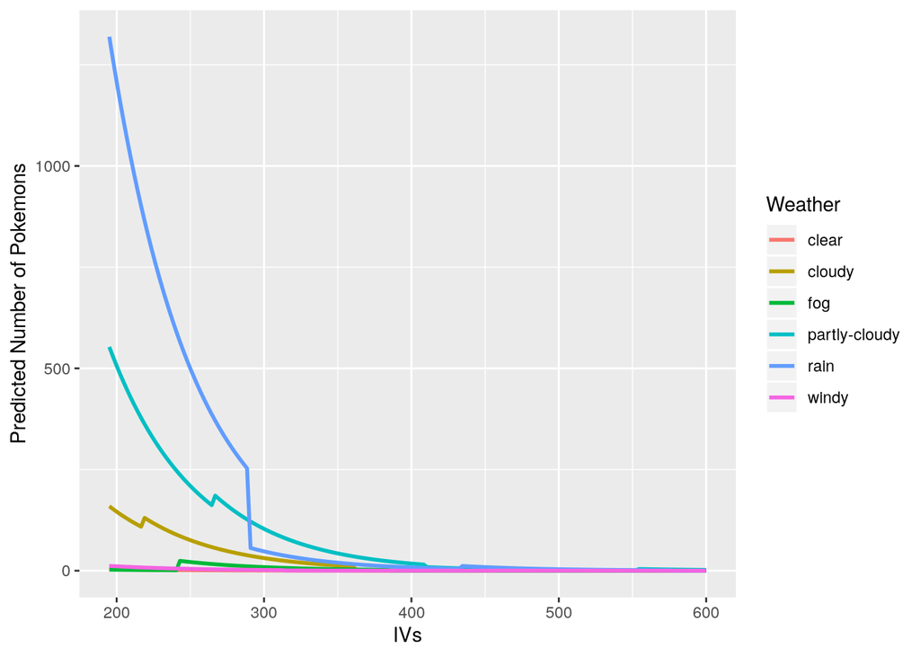

```r
ggplot(new.data, aes(BS, n)) +
  geom_line(aes(color = Weather), size = 1) +
  labs(x = "IVs", y = "Predicted Number of Pokemons")
```

Project files: https://github.com/aleedk1123/rpokemongo